# IO

王一帆

江苏企业大学

# File

File对象封装了路径名和引用,该引用指向硬盘上可能存在也可能不存在的物理 文件或目录.创建File并不意味着文件或目录实际上就存在.

# File的作用

- 检查针对物理文件系统所封装的路径名,看它是否和一个实际的文件或目录相对应
- 可以创建文件流对象

# 课堂练习

- 查看API,查看File类的方法
- 列出指定目录下的所有文件包括目录
- 只列出目录下的子目录(可以想出几种方法,使用你能想到的最简单的方式实现)

# 答案

```java
import java.io.File;

public class DirList {
    public static void main(String args[]) {
        String dirname = "/tmp";
        File f1 = new File(dirname);
        if (f1.isDirectory()) {
            System.out.println( "Directory of " + dirname);
            String s[] = f1.list();
            for (int i=0; i < s.length; i++) {
                File f = new File(dirname + "/" + s[i]);
                if (f.isDirectory()) {
                    System.out.println(s[i] + " is a directory");
                } else {
                    System.out.println(s[i] + " is a file");
                }
            }
        } else {
            System.out.println(dirname + " is not a directory");
        }
    }
}
```

# 课后练习

- 查看API,熟练掌握File类的方法
- IO

# 基本概念

- 在Java中对IO类库一般使用流这个抽象概念,它表示任何有能力产出数据的数 据源对象或有能力接收数据的接收端对象.
- 流屏蔽了实际的IO设备处理数据的细节,是对IO设备的抽象
- 流的方向是以程序(内存)为主体.所以从文件或其它设备获取称为为"读入",写到文件或其 它设备称为"写出"

# 结构图

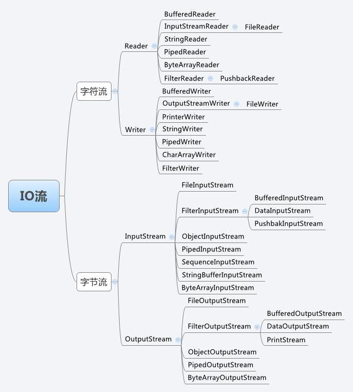

# IO流的分类

- 根据处理数据类型的不同分为：字符流和字节流
- 根据数据流向不同分为：输入流和输出流
- 所有的输入字节流均继承自:InputStream
- 所有的输出字节流均继承自:OutputStream
- 所有的输入字符流均继承自:Reader
- 所有的输出字符流均继承自:Writer
- 字符流和字节流可以通过:InputStreamReader和OutputStreamWriter来关联

# IO流的实现

- 有如下类

```java
public interface InputStream{
    public abstract String read();
}

public class MyInputStream extends InputStream{
    public String read(){
        return "读取一个字节";
    }
}
```

- 在不修改该类的情况下,需要新增一个能一次性读取一个字符的方法!(一个字符等于 几个字节?)你如何处理?
- 我还需要一个能一次性读一行的方法!怎么办?
- 我想同时拥有读取一个字符和一行内容的方法呢?

# 实现

```java
public class MyInputStream2 extends InputStream {

    private InputStream inputStream;

    public MyInputStream2(InputStream inputStream){
        this.inputStream = inputStream;
    }

    @Override
    public String read() {
        return this.inputStream.read();
    }

    public String readChar() {
        return inputStream.read()+inputStream.read();
    }
}
```

# 调用

```java
public class Test {
    public static void main(String[] args) {
        InputStream stream = new MyInputStream();
        System.out.println(stream.read());
        MyInputStream2 mis2 = new MyInputStream2(stream);
        System.out.println(mis2.read());
        System.out.println(mis2.readChar());
    }
}
```

# 装饰模式

- 装饰模式是在不必改变原类文件和使用继承的情况下，动态地扩展一个对象的功能。它是通过创建一个包装对象，也就是装饰来包裹真实的对象。

# 课堂练习

- 请实现读取一行的方法(假设依次打印四次)
- 是否有代码重复?如何重构?
- 并修改调用代码,创建一个既包含读取一个字符的方法又包含读取一行的方法

# FileInputStream

```java
public class Test {
  public static void main(String[] args) {
      int b = 0;
      FileInputStream in = new FileInputStream("d:\\test.txt");
      long num = 0;
      while((b=in.read())!=-1){
        System.out.print((char)b);
        num++;
      }
      in.close();
  }
}
```

# FileOutputStream

```java
import java.io.*;
public class Test {
    public static void main(String[] args) {
        int b = 0;
        FileInputStream in = new FileInputStream("d:/test.txt");
        FileOutputStream out = new FileOutputStream("d:/test2.txt");
        while((b=in.read())!=-1){
            out.write(b);
    }
    in.close();
    out.close();
    }
}
```

# try-catch

```java
import java.io.*;
public class Test {
    public static void main(String[] args) {
        int b = 0;
        FileInputStream in = null;
        FileOutputStream out = null;
        try {
            in = new FileInputStream("d:/test.txt");
            out = new FileOutputStream("d:/test2.txt");
            while((b=in.read())!=-1){
                out.write(b);
            }
            in.close();
            out.close();
        } catch (Exception e) {
            e.printStackTrace();
        } finally {
            try {
                in.close();
            } catch (IOException e) {
                e.printStackTrace();
            }
            try {
                out.close();
            } catch (IOException e) {
                e.printStackTrace();
            }
        }
    }
}
```

# try-resource-catch

```java
import java.io.*;
public class Test {
    public static void main(String[] args) {
        int b = 0;
        try (FileInputStream in = new FileInputStream("d:/test.txt");
             FileOutputStream out = new FileOutputStream("d:/test2.txt")){

            while((b=in.read())!=-1){
                out.write(b);
            }
            in.close();
            out.close();
        } catch (Exception e) {
            e.printStackTrace();
        }
    }
}
```

# FileReader

```java
import java.io.*;
public class Test {
    public static void main(String[] args) {
        FileReader fr = null;
        int c = 0;
        fr = new FileReader("d:\\test.txt");
        int ln = 0;
        while ((c = fr.read()) != -1) {
            System.out.print((char)c);
        }
        fr.close();
    }
}
```

# FileWriter

```java
import java.io.*;
public class Test {
    public static void main(String[] args) {
        FileWriter fw = null;
        fw = new FileWriter("d:\\test.txt");
        for(int c=0;c<=50000;c++){
            fw.write(c);
        }
        fw.close();
    }
}
```

# BufferStream

```java
import java.io.*;
public class Test {
  public static void main(String[] args) {
      BufferedWriter bw = new BufferedWriter(new FileWriter("d:\\test.txt"));
      BufferedReader br = new BufferedReader(new FileReader("d:\\test2.txt"));
      String s = null;
      for(int i=1;i<=100;i++){
        s = String.valueOf(Math.random());
        bw.write(s);
        bw.newLine();
      }
      bw.flush();
      while((s=br.readLine())!=null){
        System.out.println(s);
      }
      bw.close();
      br.close();
  }
}
```

# PrintStream

```java
import java.io.*;
public class Test {
    public static void main(String[] args) {
        PrintStream ps = new PrintStream(fos);
        FileOutputStream fos = new FileOutputStream("d:\\test.txt");
        if(ps != null){
            System.setOut(ps);
        }
        int ln = 0;
        for(char c = 0; c <= 60000; c++){
            System.out.print(c+ " ");
            if(ln++ >=100){ System.out.println(); ln = 0;}
        }
    }
}
```

# DataStream

```java
import java.io.*;
public class Test {
    public static void main(String[] args) {
        ByteArrayOutputStream baos = new ByteArrayOutputStream();
        DataOutputStream dos = new DataOutputStream(baos);
        dos.writeDouble(Math.random());
        dos.writeBoolean(true);
        ByteArrayInputStream bais = new ByteArrayInputStream(baos.toByteArray());
        System.out.println(bais.available());
        DataInputStream dis = new DataInputStream(bais);
        System.out.println(dis.readDouble());
        System.out.println(dis.readBoolean());
        dos.close();
        dis.close();
  }
}
```

# ObjectIO

```java
import java.io.*;
public class Test {
    public static void main(String args[]) throws Exception {
        Circle circle = new Circle();
        circle.setRadius(10);
        System.out.println(circle.area());
        FileOutputStream fos = new FileOutputStream("d:/obj.bak");
        ObjectOutputStream oos = new ObjectOutputStream(fos);
        oos.writeObject(t);
        oos.flush();
        oos.close();

        FileInputStream fis = new FileInputStream("d:/obj.bak");
        ObjectInputStream ois = new ObjectInputStream(fis);
        Circle tReaded = (Circle)ois.readObject();
        System.out.println(circle.area());
    }
}
```

# 课后练习

- 查询API熟悉如上类的操作
- 修改如上代码,完善try...catch
- 尝试使用try(resource)...catch

# 课后作业

- 创建一个叫SortedDirList的类，它具有一个可以接受文件路径信息，并能构建该路径下所有文件的排序目录列表的构造方法。向这个类添加两个重载的list()方法：一个产生整个列表，另一个产生与其参数相匹配的列表的子集
- 打开一个文本文件，每次读取一行。将每行作为一个String读入，并将那个String对象置入一个LinkedList中。按照相反的顺序打印出LinkedList中的所有行
- 修改上面的练习，使要读取的文件的名字以命令行参数的形式来提供
- 修改上面的练习，强制ArrayList中的所有行都变成大写形式，并将结果发给System.out

# 课后作业

- 修改上面的练习，另其接受附加命令行参数，用来表示要在文件中查找的单词。打印出所有包含了欲查找单词的所有文本行
- 修改上面的练习，同时打开一个文件，将文本写入其中。将 LinkedList中的各行随同行号一起写入文件
- 写一个程序，它接受标准输入并将所有字符转为大写，然后将结果写入到标准输入流中。
- 创建一个Serializable类，它包含一个对第二个Serializable类的对象的应用。创建你的类的实例，将其序列化到硬盘上，然后恢复它，并验证这个过程可以正常的工作。